# Homework 4: Functions and Histograms

Please complete this notebook by filling in the cells provided. When you’re done:

1. Select `Run All` from the `Cell` menu to ensure that you have executed all cells.
2. Select `Download as HTML (.html)` from the `File` menu
3. Inspect your file to make sure it looks like it should.
4. Upload your file to Moodle.

Run the cell below to prepare the notebook and the tests. **Passing the automatic tests does not guarantee full credit on any question.** The tests are provided to help catch some common errors, but it is *your* responsibility to answer the questions correctly.

```python
# Run this cell to set up the notebook, but please don't change it.
import numpy as np
from datascience import *

# These lines do some fancy plotting magic.
import matplotlib
%matplotlib inline
import matplotlib.pyplot as plt
plt.style.use('fivethirtyeight')
import warnings
warnings.simplefilter('ignore', FutureWarning)
```

## 1. Predicting Temperatures

In this exercise, we will try to predict the weather in California using the prediction method discussed in [section 8.1 of the textbook](https://inferentialthinking.com/chapters/08/1/Applying_a_Function_to_a_Column.html). Much of the code is provided for you; you will be asked to understand and run the code and interpret the results.

The US National Oceanic and Atmospheric Administration (NOAA) operates thousands of climate observation stations (mostly in the US) that collect information about local climate. Among other things, each station records the highest and lowest observed temperature each day. These data, called "Quality Controlled Local Climatological Data," are publicly available here.

`temperatures.csv` contains an excerpt of that dataset. Each row represents a temperature reading in Fahrenheit from one station on one day. (The temperature is actually the highest temperature observed at that station on that day.) All the readings are from 2015 and from California stations.

```python
temperatures = Table.read_table("~/DS_113_S23/HW/HW_4/temperatures.csv")
temperatures
```

| Temperature | Date | Latitude | Longitude | Station name |
| --- | --- | --- | --- | --- |
| 67 | 1013 | 40.9781 | -124.109 | Arcata/Eureka |
| 63 | 811 | 38.3208 | -123.075 | Bodega |
| 94 | 706 | 39.1019 | -121.568 | Marysville |
| 59 | 1211 | 36.9358 | -121.789 | Watsonville |
| 111 | 620 | 32.8342 | -115.579 | Imperial |
| 88 | 821 | 33.9 | -117.25 | Riverside |
| 68 | 606 | 33.938 | -118.389 | Los Angeles |
| 66 | 205 | 37.2847 | -120.513 | Merced |
| 89 | 902 | 39.49 | -121.618 | Oroville |
| 105 | 728 | 34.8536 | -116.786 | Daggett |

... (990 rows omitted)

Here is a scatter plot:

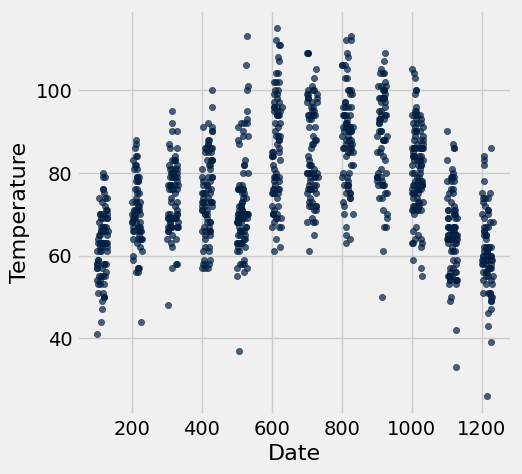

```python
temperatures.scatter("Date", "Temperature")
```

Each entry in the column "Date" is a number in MMDD format, meaning that the last two digits denote the day of the month, and the first 1 or 2 digits denote the month.

**Question 1.** Why do the data form vertical bands with gaps?

Since the last two digits represent the day of the month, the maximum number that can be the last two digits is 31. Therefore, the column "Date" does not have numbers that have the last two digits exceeding 31, which makes the gap formed by vertical bands.

Let us solve that problem. We will convert each date to the number of days since the start of the year.

```python
def get_month(date):
    """The month in the year for a given date.

    >>> get_month(315)
    3
    """
    return int(date / 100)

def get_day_in_month(date):
    """The day in the month for a given date.

    >>> get_day_in_month(315)
    15
    """
    return date % 100

DAYS_IN_MONTHS = Table().with_columns(
    "Month", np.arange(1, 12+1),
    "Days in Month", make_array(31, 28, 31, 30, 31, 30, 31, 31, 30, 31, 30, 31))

# A table with one row for each month.  For each month, we have
# the number of the month (e.g. 3 for March), the number of
# days in that month in 2015 (e.g. 31 for March), and the
# number of days in the year before the first day of that month
# (e.g. 0 for January or 59 for March).
DAYS_SINCE_YEAR_START = DAYS_IN_MONTHS.with_column(
    "Days since start of year", np.cumsum(DAYS_IN_MONTHS.column("Days in Month")) - DAYS_IN_MONTHS.column("Days in Month"))

def days_since_year_start(month):
    """The number of days in the year before this month starts.

    month should be the number of a month, like 3 for March.

    >>> days_since_year_start(3)
    59
    """
    return DAYS_SINCE_YEAR_START.where("Month", are.equal_to(month))\
                                .column("Days since start of year")\
                                .item(0)

# First, extract the month and day for each reading.
with_month_and_day = temperatures.with_columns(
    "Month", temperatures.apply(get_month, "Date"),
    "Day in month", temperatures.apply(get_day_in_month, "Date"))
# Compute the days-since-year-start for each month and day.
fixed_dates = with_month_and_day.apply(days_since_year_start, "Month") + with_month_and_day.column("Day in month")
# Add those to the table.
with_dates_fixed = with_month_and_day.with_column("Days since start of year", fixed_dates).drop("Month", "Day in month")
with_dates_fixed
```

| Temperature | Date | Latitude | Longitude | Station name | Days since start of year |
| --- | --- | --- | --- | --- | --- |
| 67 | 1013 | 40.9781 | -124.109 | Arcata/Eureka | 286 |
| 63 | 811 | 38.3208 | -123.075 | Bodega | 223 |
| 94 | 706 | 39.1019 | -121.568 | Marysville | 187 |
| 59 | 1211 | 36.9358 | -121.789 | Watsonville | 345 |
| 111 | 620 | 32.8342 | -115.579 | Imperial | 171 |
| 88 | 821 | 33.9 | -117.25 | Riverside | 233 |
| 68 | 606 | 33.938 | -118.389 | Los Angeles | 157 |
| 66 | 205 | 37.2847 | -120.513 | Merced | 36 |
| 89 | 902 | 39.49 | -121.618 | Oroville | 245 |
| 105 | 728 | 34.8536 | -116.786 | Daggett | 209 |

... (990 rows omitted)

**Question 2.** In the cell above, what is the value of this expression?

```
np.cumsum(DAYS_IN_MONTHS.column("Days in Month")) - DAYS_IN_MONTHS.column("Days in Month")
```

Describe its type and what its value (or the values in it, if it's an array or table) means.

*Hint:* You can write `np.cumsum?` to get documentation for the function `cumsum`.

```python
# You can write code in this cell to help you answer this
# question, if you want to.

np.cumsum(DAYS_IN_MONTHS.column("Days in Month")) - DAYS_IN_MONTHS.column("Days in Month")
```

```
array([  0,  31,  59,  90, 120, 151, 181, 212, 243, 273, 304, 334])
```

Its type is array and it returns an array of numbers related to the days in a year. The first element in the array is 0, which is before the year begins, and the rest of the array adds up the days of the month.

*np.cumsum returns the cumulative sum of the elements along a given axis.

Now we can make a better scatter plot.

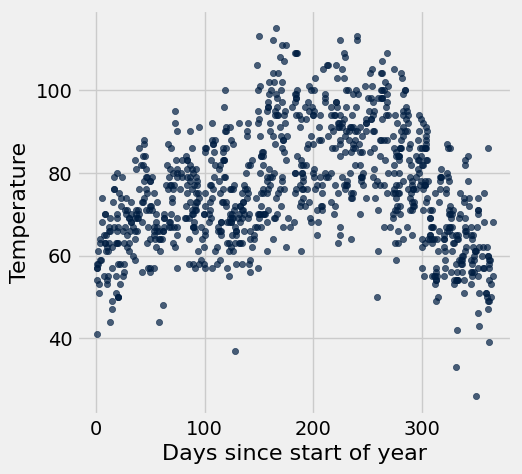

```python
with_dates_fixed.scatter("Days since start of year", "Temperature")
```

Let's do some prediction. For any reading on any day, we will predict its value using all the readings from the week before and after that day. A reasonable prediction is that the reading will be the average of all those readings. We will package our code in a function.

```python
PREDICTION_RADIUS = 7

def predict_temperature(day):
    """A prediction of the temperature (in Fahrenheit) on a given day at some station.
    """
    nearby_readings = with_dates_fixed.where("Days since start of year", are.between_or_equal_to(day - PREDICTION_RADIUS, day + PREDICTION_RADIUS))
    return np.average(nearby_readings.column("Temperature"))
```

**Question 3.** Suppose you're planning a trip to Yosemite for Thanksgiving break this year, and you'd like to predict the temperature on November 26 (the Saturday after Thanksgiving). Use `predict_temperature` to compute a prediction for a temperature reading on that day.

*Hint:* In addition to `predict_temperature`, another function we wrote earlier will be helpful.

```python
## days since the year start (thanksgiving day)
thanksgiving_day = days_since_year_start(get_month(1126)) + get_day_in_month(1126)
thanksgiving_day
## predicted temperature on thanksgiving day
thanksgiving_prediction = predict_temperature(thanksgiving_day)
thanksgiving_prediction
```

```
64.319148936170208
```

Below we have computed a predicted temperature for each reading in the table and plotted both. (It may take a **minute or two** to run the cell.)

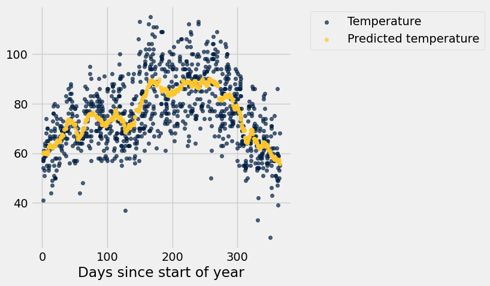

```python
with_predictions = with_dates_fixed.with_column(
    "Predicted temperature",
    with_dates_fixed.apply(predict_temperature, "Days since start of year"))
with_predictions.select("Days since start of year", "Temperature", "Predicted temperature")\
                .scatter("Days since start of year")
```

**Question 4.** How many times was the first line of the body of the function `predict_temperature` (the one that starts with `nearby_readings = ...`) executed when you ran the cell above?

**Question 5.** The scatter plot is called a *graph of averages*. In the [example in the textbook](https://inferentialthinking.com/chapters/08/1/Applying_a_Function_to_a_Column.html#example-prediction), the graph of averages roughly followed a straight line. Is that true for this one? Using your knowledge about the weather, explain why or why not.

For this graph, the graph of averages does not follow a staight line. It is rather a curved line. This is because the graph is about the predicted temperature of a year. There are seasonal changes in a year, which makes the first few days and the last days to have the coldest temperature because those days are winter. And the highest points are the days in summer, which have the highest temperatures in a year.

**Question 6.** According to the [Wikipedia article](https://en.wikipedia.org/wiki/Climate_of_California) on California's climate, "[t]he climate of California varies widely, from hot desert to subarctic." Suppose we limited our data to weather stations in a smaller area whose climate varied less from place to place (for example, the state of Vermont, or the San Francisco Bay Area). If we made the same graph for that dataset, in what ways would you expect it to look different?

The graph will also be a curved graph, gradually increasing and at some point gradually decreasing. However, the rate of change, which is the slope, would be less than the previous graph.

## 2. Reading Documents

Often, we have to work with data that aren't in CSV format, but instead come in some less nice form. In this exercise, we'll look at the text of some Reuters news reports from 1987. Our dataset doesn't include *all* the news reports from that year, but it includes 1,000 of them. Reuters doesn't say how the articles were selected.

We've put the text of all the articles in a file called `reuters.txt`. The cell below loads that file into a single big string and prints a few thousand characters, which is just enough to see one full article and the start of the next. (Don't try to print the whole thing, because it's very long.)

**You will need to download the file 'reuters.txt' and then upload it to the folder where you have this notebook saved.**

```python
# Just run this cell to load the dataset as one big string of text.
with open('reuters.txt', 'r') as file:
    big_reuters_string = file.read()

print("{:.5000}\n[...]".format(big_reuters_string))
```

```
<reuters cgisplit="PUBLISHED-TESTSET" lewissplit="NOT-USED" newid="12603" oldid="21460" topics="YES">
<date> 2-APR-1987 11:11:23.62</date>
<topics><d>livestock</d><d>carcass</d><d>trade</d></topics>
<places><d>usa</d><d>japan</d></places>
<people><d>lyng</d></people>
<orgs></orgs>
<exchanges></exchanges>
<companies></companies>
<unknown>
C G L
f1408reute
u f BC-/LYNG-SETS-TOUGH-U.S.   04-02 0141</unknown>
<text>
<title>LYNG SETS TOUGH U.S. STANCE WITH JAPAN ON BEEF</title>
<dateline>    WASHINGTON, April 2 - </dateline>U.S. Agriculture Secretary Richard
Lyng warned Japan that the failure to remove a longstanding
import quota on Japanese beef might spark a protectionist
response in the United States.
    "Given the protectionist mood in the Congress and the
country, if I were a leader in Japan I would certainly be very
concerned...and the failure to remove it (the beef quota) might
be very serious," Lyng told a group of U.S cattlemen.
    Lyng said he and Trade Representative Clayton Yeutter,
during a visit to Japan later this month, will demand "total
elimination" of the beef import quota by April 1988.
    The current dispute with Japan over semiconductor may
strengthen the U.S. stance in farm trade negotiations, Lyng
said, because Japan does not want a trade war with the U.S.
    Lyng dismissed recent statements in Tokyo that Japan might
retaliate against U.S. products as a result of the
semiconductor dispute.
    "They (Japan) aren't going to pick a fight with us," Lyng
said, adding that with its huge bilateral trade surplus Japan
has more to lose in a trade war than the United States.
    Lyng told the U.S. cattlemen that the quota on Japanese
beef imports does not allow consumers there an adequate choice
in food purchases.
    He said in addition to beef, the U.S. will press for
eliminiation of import barriers on Japan's citrus and rice as
well.
```

[output cut: 66 more lines]

```
<exchanges></exchanges>
<companies></companies>
<unknown>
F
f1735reute
r f BC-BIOGEN-<BGNF>-GETS-PA   03-26 0103</unknown>
<text>
<title>BIOGEN <BGNF> GETS PATENT FROM EUROPEAN OFFICE</title>
<dateline>    CAMBRIDGE, Mass., March 26 - </dateline>Biogen Inc said the European
Patent Office granted it a patent covering certain proteins
used to produce a hepatitis B vaccine through genetic
engineering techniques.
    Robert Gottlieb, Biogen spokesman, said the company has
licensed the vacci
[...]
```

There's a bunch of weird text for each article. Each article is separated from its neighbors by the string `"***ARTICLE***"`.

**Question 1.** Use the String method `split` to make an array of the text of all the articles. That is, each entry of this array should be the text of one article. Put that array in a new table called `reuters` as a column with the name "Raw text".

*Hint:* When you split the articles correctly, you should see that each article starts with `"<reuters..."` and ends with `"...</reuters>"`. There should be 1,000 articles.

*Hint 2:* As an example, `"steamcleaner".split("ea")` is the same as `make_array('st', 'mcl', 'ner')`. So you want to split the big string that contains all the data, splitting with the text `"***ARTICLE***"`.

**Note: The text will not actually show up in the table. It will look empty, but it is not.**

```python
reuters = Table().with_column(
        "Raw text", (big_reuters_string.split("***ARTICLE***"))
    )
reuters
```

| Raw text |
| --- |

... (990 rows omitted)

Each article has a line containing its title that looks something like this:

```
<title>LYNG SETS TOUGH U.S. STANCE WITH JAPAN ON BEEF</title>
```

You could find that yourself for a few of the articles, but it would be very tedious to do it for all 1,000 articles. So we'll write code to do it instead.

**Question 2.** Below, we've written a function called `get_text_in_markers` that will help you find the title text for an article. Use it to write a function called `get_title`, which is also documented below.

```python
# This function is provided for you to use.  Read at least
# its documentation (the stuff at the beginning in red).
# You can also type in get_text_in_markers? somewhere and
# run it to see the documentation in a slightly nicer form.
# We haven't used any tools you haven't seen yet, so it
# wouldn't hurt to read the code itself, too.
def get_text_in_markers(text, marker):
    """Finds the part of a piece of text that's between specified markers.

    Parameters
    ----------
    text : str
        The text in which you want to find something.
    marker : str
        The name of the marker that delimits the part of the
        text you want to grab.  In the text itself, this string
        will be surrounded by "<>" or "</>", but don't include
        those angle brackets in this argument.

    Returns
    -------
    str
        The parts of the text that are inside the markers.

    Examples
    --------
    >>> get_text_in_markers("stuff <interesting>yay exciting</interesting> more stuff", "interesting")
    'yay exciting'
    """
    start_marker = "<{}>".format(marker)
    end_marker = "</{}>".format(marker)
    split_before = np.array(text.split(start_marker))
    marker_text_and_after = split_before.item(1)
    split_on_end_marker = np.array(marker_text_and_after.split(end_marker))
    return split_on_end_marker.item(0)

# Fill in this function.
def get_title(article_text):
    """Takes the text of an article and returns its title."""
    ## title has the marker <title>
    title = get_text_in_markers(article_text,"title")
    return title

# When you're done, this should produce 'LYNG SETS TOUGH U.S. STANCE WITH JAPAN ON BEEF'.
get_title(reuters.column("Raw text").item(0))
```

```
'LYNG SETS TOUGH U.S. STANCE WITH JAPAN ON BEEF'
```

**Question 3.** Now use your function to find the title of every article in `reuters`. Create a new table called `with_titles` that's a copy of `reuters` with an extra column named "Title" that contains these titles.

*Note:* This might take a few seconds to run.

```python
with_titles = reuters.with_column("Title", (reuters.apply(get_title, "Raw text")))
with_titles
```

[output not shown]

... (990 rows omitted)

Now we'll go through a similar process to get the date of each article. In each article, the date is on its own line, separated from the rest of the article by `<date>` and `</date>` markers. You can check one of the articles for an example.

**Question 4.** Write a function called `get_date`. It should take as its argument the whole text of an article and return the date. The date should be just the day of the year (so January 1 is day 1, and February 1 is day 32, since January has 31 days). Note that all the articles are from the year 1987, so the year is irrelevant.

We've written a function called `date_string_to_day` that will help you do this.

```python
# This function is provided for you to use.  Read at least
# its documentation (the stuff at the beginning in red).
def date_string_to_day(date_string):
    """Converts a string that looks like a date into the day of the year.

    Parameters
    ----------
    date_string : str
        Text that contains a date in any reasonable format.
        For example, "September 13, 1994" or "9/13/94" or
        "13-SEP-1994 15:02:20.00" all work.

    Returns
    -------
    int
        The day of the year that the date represents.

    Examples
    --------
    >>> date_string_to_day("January 3, 2016")
    3

    >>> date_string_to_day("February 4, 2000")
    35
    """
    from dateutil import parser
    import re
    # Some of the Reuters dates have extraneous text at the end.
    # This removes that text.
    date_part = re.sub(" [A-Z]*$", "", date_string)
    try:
        date = parser.parse(date_part)
    except:
        print("Failed on", date_string)
    day_in_year = date.timetuple().tm_yday
    return day_in_year

# Fill in this function.
def get_date(article_text):
    """Takes the text of an article and returns its date."""
    ## date has the marker <date>
    date_text = get_text_in_markers(article_text,"date")
    day_in_year = date_string_to_day(date_text)
    return day_in_year

# When you're done, this should produce 92.
get_date(reuters.column("Raw text").item(0))
```

```
92
```

**Question 5.** Use your function to find the date of every article in `with_titles`. Create a new table called `with_dates` that's a copy of `with_titles` with an extra column named "Date" that contains the dates.

```python
with_dates = with_titles.with_column("Date", (reuters.apply(get_date, "Raw text")))
with_dates
```

[output not shown]

... (990 rows omitted)

**Question 6.** There was a series of earthquakes in Ecuador on March 6, 1987. Most Reuters news stories about Ecuador from that period were related to the earthquake or its political and economic consequences. Find out when Reuters reported on the earthquake by making a histogram of all the dates of the articles whose *titles* include the word `"ECUADOR"`. Use bins of width 3.